# MWI: Compare ARC2 and CHIRPS

### Geographic comparison

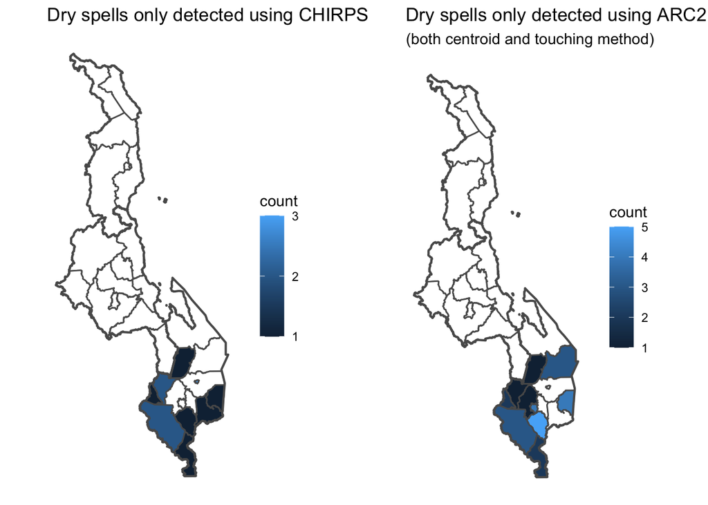

```r
arc2_missing_plot <- arc2_chirps_df %>%
  filter(chirps_ds, !arc2_touch_ds) %>%
  group_by(pcode) %>%
  summarize(count = n()) %>%
  right_join(adm2, by = c("pcode" = "ADM2_PCODE")) %>%
  st_as_sf() %>%
  ggplot() +
  geom_sf(aes(fill = count)) +
  scale_fill_gradient(na.value = "white",
                      breaks = 1:5) +
  geom_sf(data = adm1, fill = NA, size = 0.75) +
  coord_sf(datum = NA) +
  theme_minimal() +
  labs(title = "Dry spells only detected using CHIRPS") +
  theme(plot.title.position = "plot")

chirps_missing_plot <- arc2_chirps_df %>%
  filter(!chirps_ds, arc2_touch_ds, arc2_centroid_ds) %>%
  group_by(pcode) %>%
  summarize(count = n()) %>%
  right_join(adm2, by = c("pcode" = "ADM2_PCODE")) %>%
  st_as_sf() %>%
  ggplot() +
  geom_sf(aes(fill = count)) +
  scale_fill_gradient(na.value = "white",
                      breaks = 1:5) +
  geom_sf(data = adm1, fill = NA, size = 0.75) +
  coord_sf(datum = NA) +
  theme_minimal() +
  labs(title = "Dry spells only detected using ARC2",
       subtitle = "(both centroid and touching method)") +
  theme(plot.title.position = "plot")

plot_grid(arc2_missing_plot, chirps_missing_plot)
```

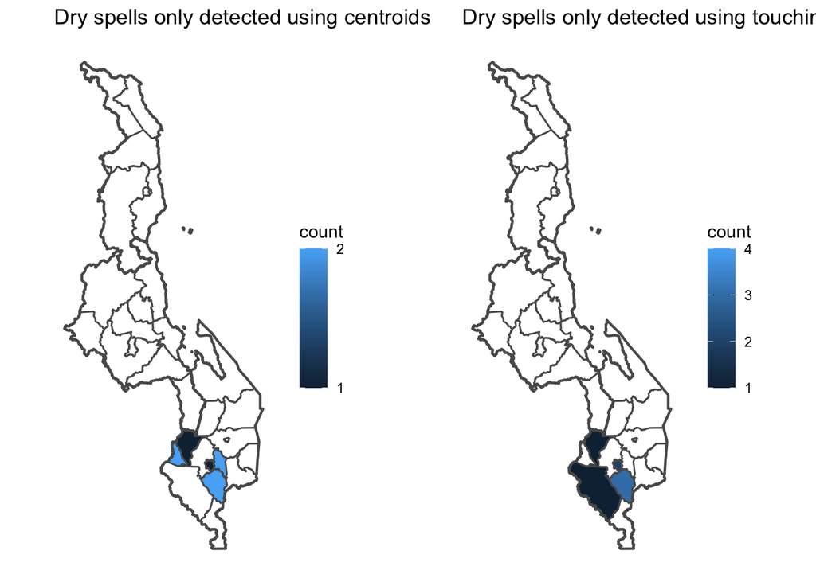

```r
centroid_missing_plot <- arc2_chirps_df %>%
  filter(arc2_centroid_ds, !arc2_touch_ds) %>%
  group_by(pcode) %>%
  summarize(count = n()) %>%
  right_join(adm2, by = c("pcode" = "ADM2_PCODE")) %>%
  st_as_sf() %>%
  ggplot() +
  geom_sf(aes(fill = count)) +
  scale_fill_gradient(na.value = "white",
                      breaks = 1:5) +
  geom_sf(data = adm1, fill = NA, size = 0.75) +
  coord_sf(datum = NA) +
  theme_minimal() +
  labs(title = "Dry spells only detected using centroids") +
  theme(plot.title.position = "plot")

touch_missing_plot <- arc2_chirps_df %>%
  filter(!arc2_centroid_ds, arc2_touch_ds) %>%
  group_by(pcode) %>%
  summarize(count = n()) %>%
  right_join(adm2, by = c("pcode" = "ADM2_PCODE")) %>%
  st_as_sf() %>%
  ggplot() +
  geom_sf(aes(fill = count)) +
  scale_fill_gradient(na.value = "white",
                      breaks = 1:5) +
  geom_sf(data = adm1, fill = NA, size = 0.75) +
  coord_sf(datum = NA) +
  theme_minimal() +
  labs(title = "Dry spells only detected using touching") +
  theme(plot.title.position = "plot")

plot_grid(centroid_missing_plot, touch_missing_plot)
```

### Trigger activation

Let’s consider if we’re using these datasets for trigger activation and how they would compare. We will only consider dry spells that are confirmed at some point in January and February. Let’s just quickly look at the number of dry spells detected this time period for each method to start.

```r
chirps_df %>%
  filter(month(chirps_confirmation) <= 2,
         str_detect(pcode, "MW3")) %>%
  mutate(trigger_year = year(chirps_confirmation)) %>%
  group_by(trigger_year) %>%
  summarize(n_triggers = n(),
            .groups = "drop")
```

```
## # A tibble: 4 × 2
##   trigger_year n_triggers
##          <dbl>      <int>
## 1         2005          5
## 2         2008         10
## 3         2010          6
## 4         2018          1
```

```r
arc2_center_df %>%
  filter(month(arc2_center_confirmation) <= 2,
         str_detect(pcode, "MW3")) %>%
  mutate(trigger_year = year(arc2_center_confirmation)) %>%
  group_by(trigger_year) %>%
  summarize(n_triggers = n(),
            .groups = "drop")
```

```
## # A tibble: 6 × 2
##   trigger_year n_triggers
##          <dbl>      <int>
## 1         2005          6
## 2         2008          8
## 3         2010         10
## 4         2011          4
## 5         2016          1
## 6         2018          3
```

```r
arc2_touch_df %>%
  filter(month(arc2_touch_confirmation) <= 2,
         str_detect(pcode, "MW3")) %>%
  mutate(trigger_year = year(arc2_touch_confirmation)) %>%
  group_by(trigger_year) %>%
  summarize(n_triggers = n(),
            .groups = "drop")
```

```
## # A tibble: 6 × 2
##   trigger_year n_triggers
##          <dbl>      <int>
## 1         2005          6
## 2         2008          8
## 3         2010         11
## 4         2011          4
## 5         2016          1
## 6         2018          1
```

```r
arc2_chirps_df %>%
  filter(arc2_touch_ds, !arc2_centroid_ds) %>%
  transmute(ADM2_EN, trigger_year = year(arc2_touch_confirmation))
```

```
## # A tibble: 11 × 2
##    ADM2_EN       trigger_year
##    <chr>                <dbl>
##  1 Thyolo                2004
##  2 Thyolo                2020
##  3 Neno                  2008
##  4 Zomba City            2002
##  5 Zomba City            2004
##  6 Zomba City            2010
##  7 Zomba City            2011
##  8 Blantyre City         2002
##  9 Blantyre City         2020
## 10 Chikwawa              2008
## 11 Thyolo                2020
```

```r
arc2_chirps_df %>%
  filter(!arc2_touch_ds, arc2_centroid_ds) %>%
  transmute(ADM2_EN, trigger_year = year(arc2_center_confirmation))
```

```
## # A tibble: 8 × 2
##   ADM2_EN       trigger_year
##   <chr>                <dbl>
## 1 Chiradzulu            2010
## 2 Chiradzulu            2018
## 3 Mwanza                2011
## 4 Mwanza                2018
## 5 Thyolo                2005
## 6 Thyolo                2016
## 7 Neno                  2010
## 8 Blantyre City         2013
```

Although the centroid method fails to capture Zomba City (due to a lack of raster centroid for ARC2 data), it seems sufficient to consider vs. CHIRPS excluding the touching raster method.